# HW 2: Visualization, Base R

## Task 3

1. What is the type of variable `Passengers`? (Categorical nominal/ordinal or Numerical discrete/continuous?) What happens if we were to make a histogram for `Passengers`? What is the problem with this graph?

```r
#Passengers is nominal and discrete. When making a histogram it could be difficult to visualize the data it masks certain categories such as cars with 1 and 3 that have no passengers meaning there should be no bar at 1 and 3.

pass_freq <- table(Cars93$Passengers)
pass_freq
```

```
##
##  2  4  5  6  7  8
##  2 23 41 18  8  1
```

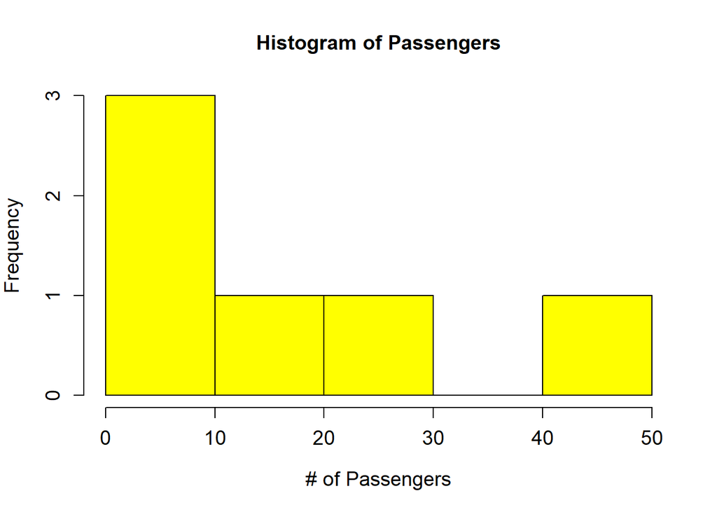

```r
hist(pass_freq, main = "Histogram of Passengers", xlab = "# of Passengers", ylab = "Frequency", cex.lab = 1.2, cex.axis = 1.2, cex.main = 1.2, col = "yellow")
```

2. Correct the problem in part (a) by creating a more appropriate visualization. Make sure to label your axes, place a title, choose a custom color as in the previous graphs. (Bonus: use factor() with levels option to display x axis values with no observations on the plot.)

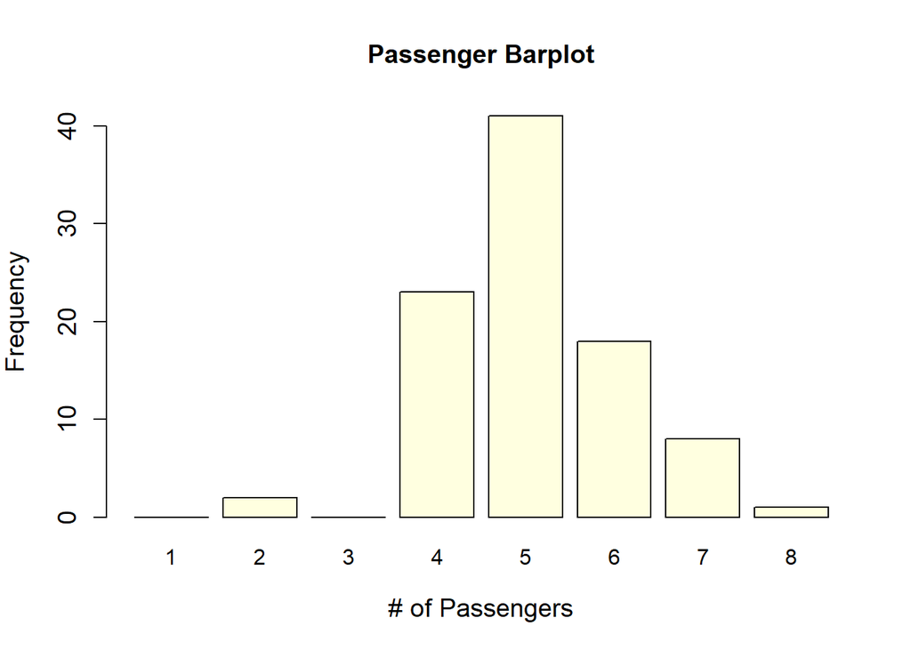

```r
passengers <- c(Cars93$Passengers)
freq_table <- table(factor(passengers, levels = c("1", "2", "3", "4", "5", "6", "7", "8")))
#colors <- c("red", "blue", "orange")
barplot(freq_table, main = "Passenger Barplot", xlab = "# of Passengers", ylab = "Frequency", cex.lab = 1.2, cex.axis = 1.2, cex.main = 1.2, col = "light yellow", ylim = c(0, max(freq_table) + 1))
```

## Task 4

1. Make a histogram of the variable `Length` (the default breaks are fine). Other aspects of the plot should be as in part (a) in Task 2.

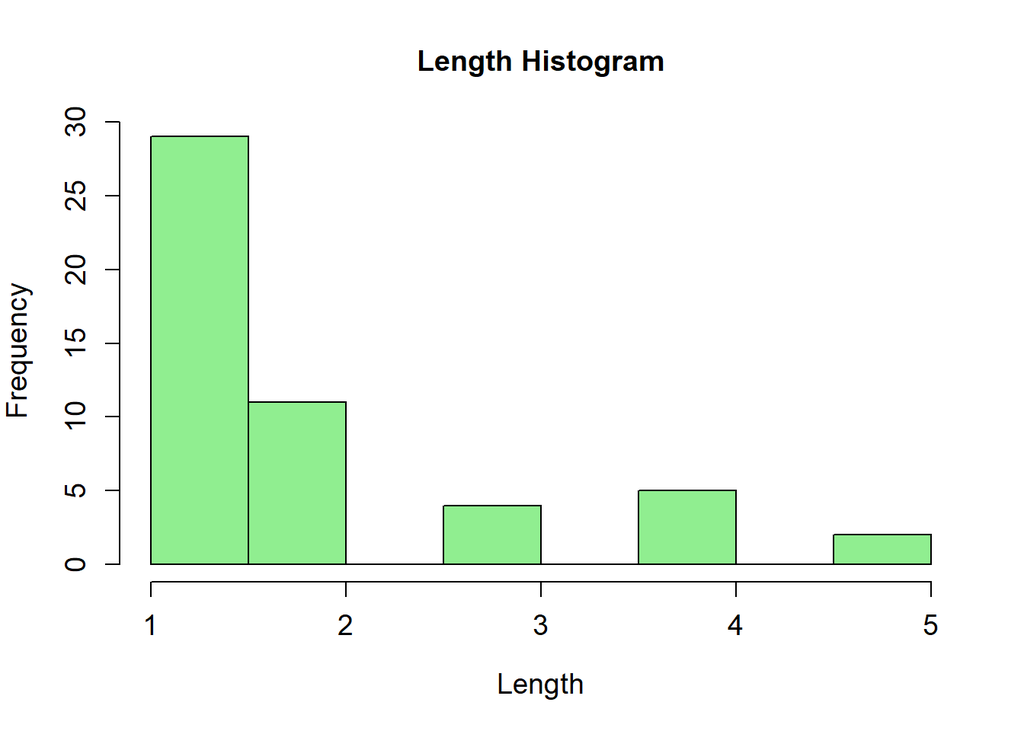

```r
length_freq <- table(Cars93$Length)
length_hist <- hist(length_freq, main = "Length Histogram", xlab = "Length", ylab = "Frequency", cex.lab = 1.2, cex.axis = 1.2, cex.main = 1.2, col ="lightgreen")
```

```r
length_hist
```

```
## $breaks
## [1] 1.0 1.5 2.0 2.5 3.0 3.5 4.0 4.5 5.0
##
## $counts
## [1] 29 11  0  4  0  5  0  2
##
## $density
## [1] 1.13725490 0.43137255 0.00000000 0.15686275 0.00000000 0.19607843 0.00000000
## [8] 0.07843137
##
## $mids
## [1] 1.25 1.75 2.25 2.75 3.25 3.75 4.25 4.75
##
## $xname
## [1] "length_freq"
##
## $equidist
## [1] TRUE
##
## attr(,"class")
## [1] "histogram"
```

```r
length_mean <- mean(Cars93$Length)
length_mean
```

```
## [1] 183.2043
```

```r
length_median <- median(Cars93$Length)
length_median
```

```
## [1] 183
```

You are done! 🏁 Don’t forget to commit and push your .Rmd file to your Github repository before the due date.